# Parameterized Report Example: Onondaga

Zachary M. Smith

2/27/2020

# Introduction

This document was created during the *2020 NABs R Markdown workshop* and will serve as an example workflow for my future use of **R Markdown**. This document will represent an exploratory analysis of macroinvertebrate metrics and environmental variable associated with Onondaga Lake.

# Workflow

1. Open R Studio
2. Create an R Project
3. Add a data folder to the R project directory
4. Create an R Markdown document
5. Use Knit to compile the document.

# Import Data

Import Zachary M. Smith’s thesis data provided by Zachary M. Smith at the R Markdown Crash Course Workshop on March 3rd, 2020.

- `unique_id` (character) unique sample ID
- `lake` (character) lake code: caz = Cazenovia lake, onon = Onondaga, and ot = Otisco
- `lat` (numeric) latitude of sampling location
- `long` (numeric) longitude of sampling location
- `substrate_size_d50` (numeric) median partical size from pebble count
- `conductivity` (numeric) specific conductivity (µS/cm)
- `richness` (numeric) taxonomic richness
- `shannon` (numeric) Shannon-Wiener diversity index values
- `pct_ephemeroptera` (numeric) relative abundance of Ephemeroptera taxa
- `pct_amphipoda` (numeric) relative abundance of Amphipoda taxa
- `pct_diptera` (numeric) relative abundance of Diptera taxa
- `dom_1` (numeric) relative abundance of the most dominant taxon observed in each sample

```r
thesis.df <- read.csv(file.path(here::here(),
                                "data",
                                "zms_thesis_metrics.csv"),
                      stringsAsFactors = FALSE)
```

# Preprocessing

Load the **tidyverse** packages into the global environment.

```r
library(tidyverse)
```

```r
thesis.df <- thesis.df %>%
  mutate(lake = case_when(
    lake %in% "caz" ~ "Cazenovia",
    lake %in% "onon" ~ "Onondaga",
    lake %in% "ot" ~ "Otisco",
    TRUE ~ "ERROR"
  ),
  lake = factor(lake, levels = c("Onondaga",
                                 "Otisco",
                                 "Cazenovia")))
```

```r
thesis.df <- thesis.df %>%
  filter(lake %in% params$lake)
```

For more details about the **DT** package visit https://rstudio.github.io/DT/.

```r
library(DT)

datatable(thesis.df, options = list(scrollX = TRUE))
```

|  | unique_id | lake | lat | long | substrate_size_d50 | conductivity | richness | shannon | pct_ephemeroptera | pct_amphipoda | pct_diptera | dom_1 |
| --- | --- | --- | --- | --- | --- | --- | --- | --- | --- | --- | --- | --- |
| 1 | onon_1_1 | Onondaga | 43.1147 | -76.2444 | 0.346410162 | 1660 | 8 | 1.34150134598141 | 0 | 0 | 98.0392156862745 | 78.4313725490196 |
| 2 | onon_10_1 | Onondaga | 43.067001 | -76.195297 | 40.86917389 | 1620 | 6 | 2.09227161867729 | 0 | 17.8217821782178 | 82.1782178217822 | 44.5544554455446 |
| 3 | onon_11_1 | Onondaga | 43.0732 | -76.204696 | 41.39626129 | 1619 | 4 | 1.95362738938473 | 0 | 35.6435643564356 | 18.8118811881188 | 35.6435643564356 |
| 4 | onon_12_1 | Onondaga | 43.081298 | -76.210998 | 0.346410162 |  | 5 | 0.953786972133288 | 0 | 0 | 98.780487804878 | 82.9268292682927 |
| 5 | onon_13_1 | Onondaga | 43.0843 | -76.215797 | 0.346410162 |  | 11 | 2.36828807760334 | 0 | 0 | 97.0873786407767 | 48.5436893203884 |
| 6 | onon_14_1 | Onondaga | 43.0886 | -76.227996 | 0.346410162 | 1517 | 7 | 1.81615109270658 | 0 | 0 | 97.8494623655914 | 44.0860215053763 |
| 7 | onon_15_1 | Onondaga | 43.0956 | -76.236099 | 26.90868529 |  | 14 | 2.94075279538478 | 0 | 25.6410256410256 | 65.8119658119658 | 28.2051282051282 |
| 8 | onon_16_1 | Onondaga | 43.103698 | -76.2425 | 0.346410162 |  | 14 | 3.29556254762953 | 0 | 8.98876404494382 | 86.5168539325843 | 16.8539325842697 |
| 9 | onon_2_1 | Onondaga | 43.111801 | -76.230003 | 37.617533 | 1593 | 9 | 2.58513187213921 | 0 | 11.9266055045872 | 40.3669724770642 | 28.4403669724771 |
| 10 | onon_3_1 | Onondaga | 43.105499 | -76.220901 | 23.55790816 | 1582 | 11 | 2.55852580179652 | 0 | 25.5639097744361 | 36.0902255639098 | 25.5639097744361 |

[output cut: 6 more lines]

```r
knitr::kable(thesis.df)
```

| unique_id | lake | lat | long | substrate_size_d50 | conductivity | richness | shannon | pct_ephemeroptera | pct_amphipoda | pct_diptera | dom_1 |
| --- | --- | --- | --- | --- | --- | --- | --- | --- | --- | --- | --- |
| onon_1_1 | Onondaga | 43.1147 | -76.2444 | 0.3464102 | 1660 | 8 | 1.3415013 | 0 | 0.000000 | 98.039216 | 78.43137 |
| onon_10_1 | Onondaga | 43.0670 | -76.1953 | 40.8691739 | 1620 | 6 | 2.0922716 | 0 | 17.821782 | 82.178218 | 44.55446 |
| onon_11_1 | Onondaga | 43.0732 | -76.2047 | 41.3962613 | 1619 | 4 | 1.9536274 | 0 | 35.643564 | 18.811881 | 35.64356 |
| onon_12_1 | Onondaga | 43.0813 | -76.2110 | 0.3464102 | NA | 5 | 0.9537870 | 0 | 0.000000 | 98.780488 | 82.92683 |
| onon_13_1 | Onondaga | 43.0843 | -76.2158 | 0.3464102 | NA | 11 | 2.3682881 | 0 | 0.000000 | 97.087379 | 48.54369 |
| onon_14_1 | Onondaga | 43.0886 | -76.2280 | 0.3464102 | 1517 | 7 | 1.8161511 | 0 | 0.000000 | 97.849462 | 44.08602 |
| onon_15_1 | Onondaga | 43.0956 | -76.2361 | 26.9086853 | NA | 14 | 2.9407528 | 0 | 25.641026 | 65.811966 | 28.20513 |
| onon_16_1 | Onondaga | 43.1037 | -76.2425 | 0.3464102 | NA | 14 | 3.2955625 | 0 | 8.988764 | 86.516854 | 16.85393 |
| onon_2_1 | Onondaga | 43.1118 | -76.2300 | 37.6175330 | 1593 | 9 | 2.5851319 | 0 | 11.926606 | 40.366973 | 28.44037 |
| onon_3_1 | Onondaga | 43.1055 | -76.2209 | 23.5579082 | 1582 | 11 | 2.5585258 | 0 | 25.563910 | 36.090226 | 25.56391 |
| onon_4_1 | Onondaga | 43.1000 | -76.2105 | 112.7435749 | 1681 | 7 | 2.1916445 | 0 | 13.461538 | 25.961538 | 45.19231 |
| onon_5_1 | Onondaga | 43.0946 | -76.2000 | 40.0318650 | 1683 | 7 | 1.0043042 | 0 | 84.112150 | 9.345794 | 84.11215 |
| onon_6_1 | Onondaga | 43.0915 | -76.1954 | 53.4730751 | 1680 | 15 | 2.1617219 | 0 | 67.179487 | 14.871795 | 63.07692 |
| onon_7_1 | Onondaga | 43.0838 | -76.1883 | 31.5412224 | 1675 | 9 | 1.7786408 | 0 | 65.979381 | 17.525773 | 65.97938 |
| onon_8_1 | Onondaga | 43.0777 | -76.1788 | 60.3337612 | 1841 | 10 | 0.9778378 | 0 | 86.666667 | 10.000000 | 86.66667 |
| onon_9_1 | Onondaga | 43.0633 | -76.1822 | 0.3464102 | 1791 | 3 | 0.8030717 | 0 | 11.111111 | 88.888889 | 83.33333 |

# Study Area

For more details about the **leaflet** package visit https://rstudio.github.io/leaflet/.

```r
library(leaflet)

pal <- colorFactor(c("#619Cff", "#F8766D", "#00BA38"),
                   domain = c("Cazenovia", "Onondaga", "Otisco"))

leaflet(data = thesis.df,
        options = leafletOptions(minZoom = 7,
                                 maxZoom = 13)) %>%
  addTiles() %>%
  addCircleMarkers(~long, ~lat,
                   fillOpacity = 0.75,
                   fillColor = ~pal(lake),
                   stroke = FALSE,
             popup = paste("Sample ID:", thesis.df$unique_id, "<br/>",
                           "Lake:", thesis.df$lake, "<br/>",
                           "Latitude:", thesis.df$lat, "<br/>",
                           "Longitude:", thesis.df$long)
             )
```

[interactive chart not shown]

# Plot

## Scatter Plot

For more details about the **plotly** package visit https://plot.ly/ggplot2/.

```r
library(plotly)

scatter.plot <- ggplot(thesis.df, aes(substrate_size_d50, pct_diptera)) +
  geom_point(aes(color = lake)) +
  geom_smooth(method = "lm")

ggplotly(scatter.plot)
```

[interactive chart not shown]

## Boxplot

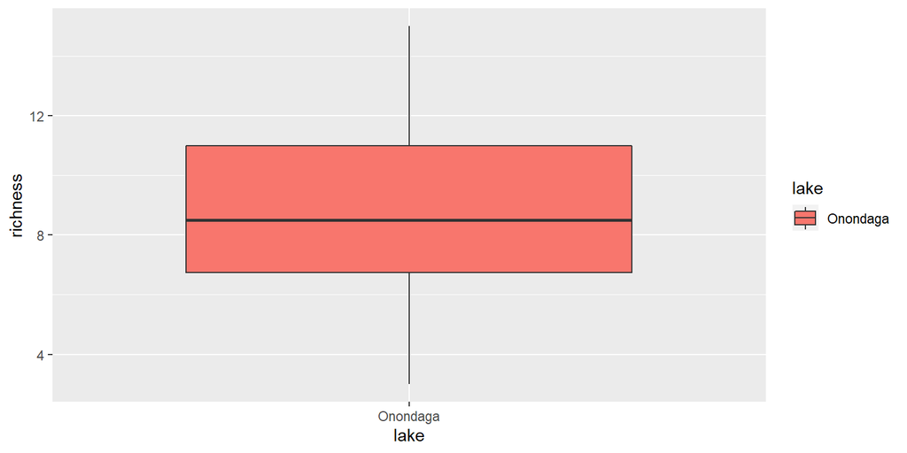

```r
ggplot(thesis.df, aes(lake, richness, fill = lake)) +
  geom_boxplot()
```

# Conclusions

1. The relative abundance of Diptera taxa in Onondaga Lake ranged from 9.3457944 to 98.7804878.
2. The median taxonomic richness observed in Onondaga Lake was 8.5.